# Chapter 08, Problem Set Key

### 8.1

The basic logistic equation,
$$\frac{\mathrm{d}N}{\mathrm{d}t} = rN\left(\frac{K − N}{K}\right)$$
says that the per capita rate of growth of a population will decrease as a linear function of the density of that population. The biological interpretation of
$$\frac{K−N}{K}$$
is the fraction of the potential environment still available to the population. Suppose that $K = 100$ and $r = 1.2$. Make a graph of $\mathrm{d}N/\mathrm{d}t$ as a function of $N$ for the logistic equation. Now suppose that another species comes along and takes up a quarter of the space originally available. How will the graph change? Repeat for a species that takes up half of the original space.

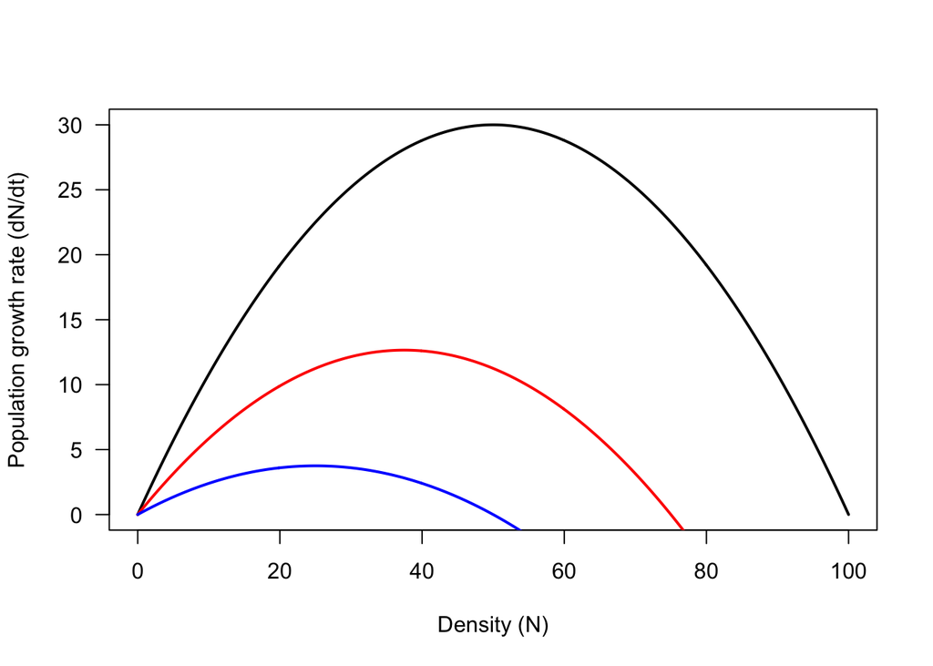

```r
N <- seq(from = 0, to = 100, length.out = 500)
dNdt1 <- 1.2*N*(100 - N)/100
dNdt2 <- 1.2*N*(100*0.75 - N)/100*0.75
dNdt3 <- 1.2*N*(100*0.5 - N)/100*0.5

plot(x = N, y = dNdt1, las = 1, xlab = "Density (N)", ylab = "Population growth rate (dN/dt)", type = "l", lwd = 2)
  lines(x = N, y = dNdt2, lwd = 2, col = "red")
  lines(x = N, y = dNdt3, lwd = 2, col = "blue")
```

### 8.2

Repeat exercise 8.1, but assume that there is a second species that is variable, so that $X$ individuals of this second species will take up $X$ parts of the original space. If you fix $N$ at 50, what will be the relationship between $\mathrm{d}N/\mathrm{d}t$ and X? First make a graph of $\mathrm{d}N/\mathrm{d}t$, and then write the equation describing the situation.

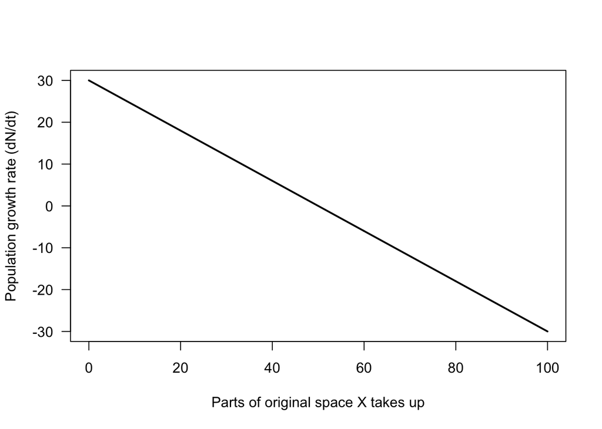

```r
X <- seq(from = 0, to = 100, length.out = 500)
N <- 50 # takes up 50 parts of N
dNdt1 <- 1.2*N*(100 - N - X)/100

plot(x = X, y = dNdt1, las = 1, xlab = "Parts of original space X takes up", ylab = "Population growth rate (dN/dt)", type = "l", lwd = 2)
```

### 8.3

Suppose that each individual of the other species (call its density $X_{8.3}$) takes up only half of the space taken up by each individual of the first species (call its density $N$). Repeat exercise 8.2 but with this new information, and make the graph of $\mathrm{d}N/\mathrm{d}t$ and compare it with the graph of exercise 8.2.

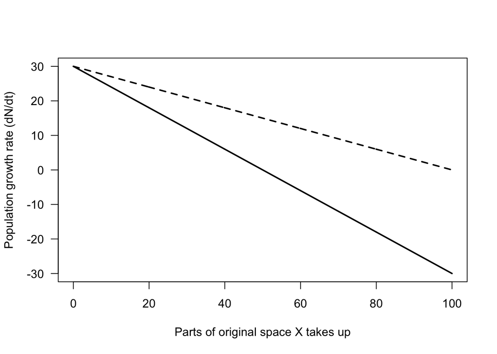

```r
X <- seq(from = 0, to = 100, length.out = 500)
N <- 50 # takes up 50 parts of N
dNdt1 <- 1.2*N*(100 - N - X)/100
dNdt1_1 <- 1.2*N*(100 - N - X*0.5)/100

plot(x = X, y = dNdt1, las = 1, xlab = "Parts of original space X takes up", ylab = "Population growth rate (dN/dt)", type = "l", lwd = 2)
  lines(x = X, y = dNdt1_1, lwd = 2, col = "black", lty = 2)
```

### 8.5

Find the equilibria for equations 4a and 4b (set the derivatives to zero and solve), and represent both in terms of $N_1$ as a function of $N_2$.

$$\begin{aligned}
\frac{\mathrm{d}N_1}{\mathrm{d}t} &= r_1N_1\left(\frac{K_1 − N_1 - \alpha _{12}N_2}{K_1}\right) \\
\frac{\mathrm{d}N_2}{\mathrm{d}t} &= r_2N_2\left(\frac{K_2 − N_2 - \alpha _{21}N_1}{K_2}\right)
\end{aligned}$$

For $\frac{\mathrm{d}N_1}{\mathrm{d}t}$, expressed as functions of $N_2$:

$$\begin{aligned}
\frac{\mathrm{d}N_1}{\mathrm{d}t} &= r_1N_1\left(\frac{K_1 − N_1 - \alpha _{12}N_2}{K_1}\right) \\
0 &= r_1N_1\left(\frac{K_1 − N_1 - \alpha _{12}N_2}{K_1}\right) \\
N^{*,1}_1 & = 0 \\
0 &= r_1\left(\frac{K_1 − N_1 - \alpha _{12}N_2}{K_1}\right) \\
0 &= r_1\left(\frac{K_1 − N_1}{K_1}\right) - r_1\frac{\alpha _{12}N_2}{K_1} \\
r_1\frac{\alpha _{12}N_2}{K_1} &= r_1\left(\frac{K_1 − N_1}{K_1}\right) \\
r_1\alpha _{12}N_2 &= r_1K_1 − N_1 \\
\alpha _{12}N_2 &= K_1 − N_1 \\
N_2 &= \frac{K_1 − N_1^{*,2}}{\alpha _{12}}
\end{aligned}$$

And the isocline for $\frac{\mathrm{d}N_2}{\mathrm{d}t}$:

$$\begin{aligned}
\frac{\mathrm{d}N_2}{\mathrm{d}t} &= r_2N_2\left(\frac{K_2 − N_2 - \alpha _{21}N_1}{K_2}\right)\\
0 &= r_2N_2\left(\frac{K_2 − N_2 - \alpha _{21}N_1}{K_2}\right)\\
0 &= r_2N_2\left(\frac{K_2 − N_2 - \alpha _{21}N_1}{K_2}\right)\\
N^{*,1}_2 & = 0 \\
0 &= r_2\left(\frac{K_2 − N_2 - \alpha _{21}N_1}{K_2}\right)\\
0 &= r_2\left(\frac{K_2 - \alpha _{21}N_1}{K_2}\right) -\frac{_2rN_2}{K_2} \\
\frac{r_2N_2}{K_2} &= r_2\left(\frac{K_2 - \alpha _{21}N_1}{K_2}\right) \\
r_2N_2 &= r_2\left(K_2 - \alpha _{21}N_1\right) \\
N_2^{*,2} &= K_2 - \alpha _{21}N_1\\
\end{aligned}$$

### 8.6

Plot both the equations you derived in exercise 8.5 for $\alpha _{12} = 0.8$, $\alpha _{21} = 0.4$, and $K_1 = K_2 = 100$ on the same graph. If you draw a line from the carrying capacity of the first species to the carrying capacity of the second species, what would that mean with regard to the point at which the two isoclines would cross?

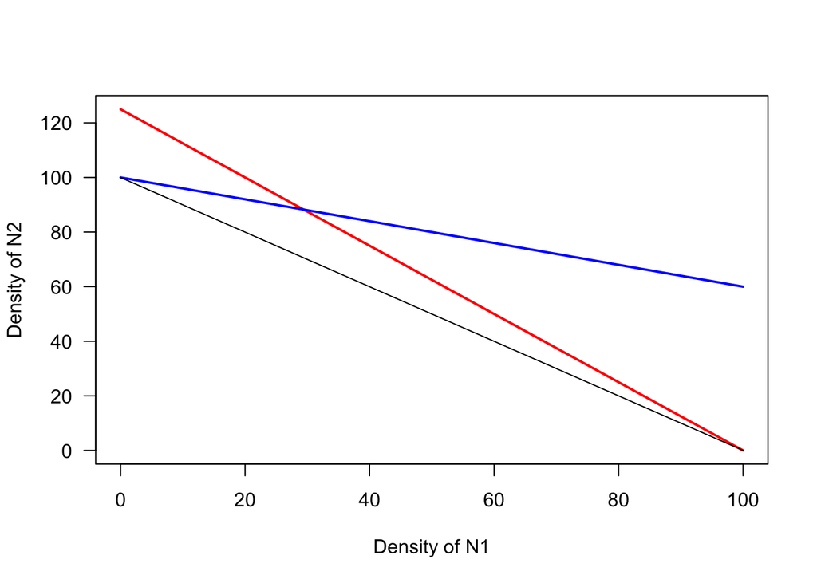

```r
N1 <- seq(from = 0, to = 100, length.out = 100)
alpha12 <- 0.8
alpha21 <- 0.4
K1 <- 100
K2 <- K1

eqn1 <- (K1 - N1)/alpha12
eqn2 <- K2 - alpha21*N1

plot(x = N1, y = eqn1, col = "red", type = "l", las = 1, lwd = 2, xlab = "Density of N1", ylab = "Density of N2")
  lines(x = N1, y = eqn2, col = "blue", lwd = 2)
  segments(x0 = 0, x1 = K1, y0 = K2, y1 = 0)
```

In this example, the joint equilibrium, where $\mathrm{d}N_1/\mathrm{d}t = \mathrm{d}N_2/\mathrm{d}t = 0$, is above the line connecting the two carrying capacities.

### 8.7

Plot both of the equations you derived in 8.5 for $\alpha _{12} = 0.8$, $\alpha _{21} = 0.6$, and $K_1 = K_2 = 150$ on the same graph. Now redraw the equation $N_1 = K_1 – \alpha _{12}N_2$ on the same graph for $K_1 = 200$, and repeat for $K_1 = 100$ and $K_1 = 50$.

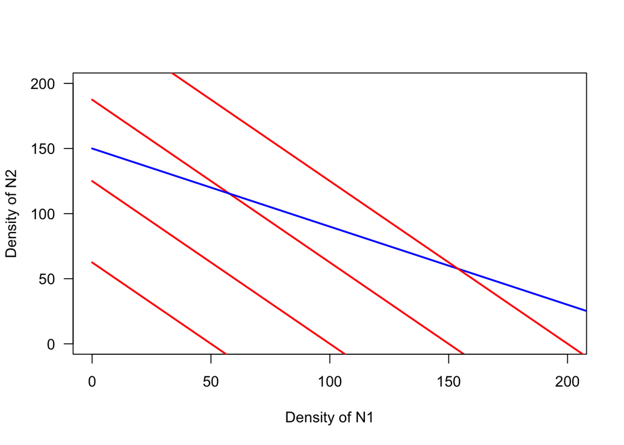

```r
N1 <- seq(from = 0, to = 250, length.out = 100)
alpha12 <- 0.8
alpha21 <- 0.6
K1 <- 150
K2 <- K1

eqn1 <- (K1 - N1)/alpha12
eqn2 <- K2 - alpha21*N1

plot(x = N1, y = eqn1, col = "red", type = "l", las = 1, lwd = 2, xlab = "Density of N1", ylab = "Density of N2", xlim = c(0, 200), ylim = c(0, 200))
  lines(x = N1, y = eqn2, col = "blue", lwd = 2)

otherKs <- c(K1 = 200, K1 = 100, K1 = 50)

for (i in 1:length(otherKs)) {
  eqn1 <- (otherKs[i] - N1)/alpha12
  lines(x = N1, y = eqn1, col = "red", lwd = 2)
}
```

In this example, the joint equilibrium, where $\mathrm{d}N_1/\mathrm{d}t = \mathrm{d}N_2/\mathrm{d}t = 0$, is above the line connecting the two carrying capacities.

### 8.8

Repeat exercise 8.7 for $\alpha _{12}$ = 1.3 and $\alpha _{21} = 1.2$.

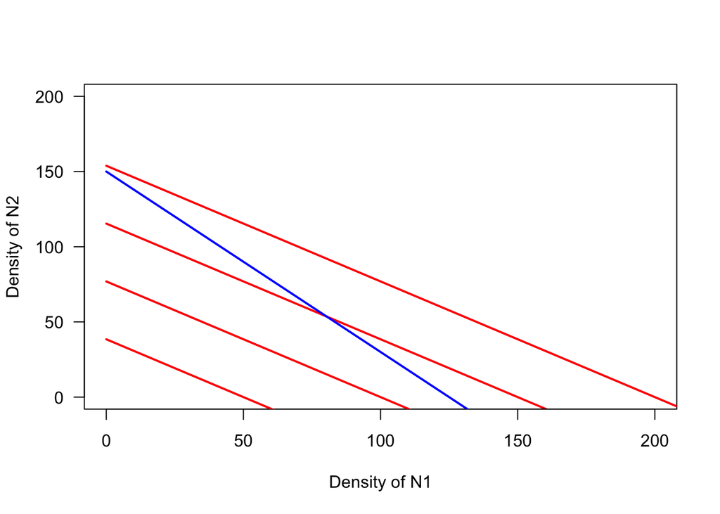

```r
N1 <- seq(from = 0, to = 250, length.out = 100)
alpha12 <- 1.3
alpha21 <- 1.2
K1 <- 150
K2 <- K1

eqn1 <- (K1 - N1)/alpha12
eqn2 <- K2 - alpha21*N1

plot(x = N1, y = eqn1, col = "red", type = "l", las = 1, lwd = 2, xlab = "Density of N1", ylab = "Density of N2", xlim = c(0, 200), ylim = c(0, 200))
  lines(x = N1, y = eqn2, col = "blue", lwd = 2)

otherKs <- c(K1 = 200, K1 = 100, K1 = 50)

for (i in 1:length(otherKs)) {
  eqn1 <- (otherKs[i] - N1)/alpha12
  lines(x = N1, y = eqn1, col = "red", lwd = 2)
}
```

# 8.X

Recreate figure 8.4.

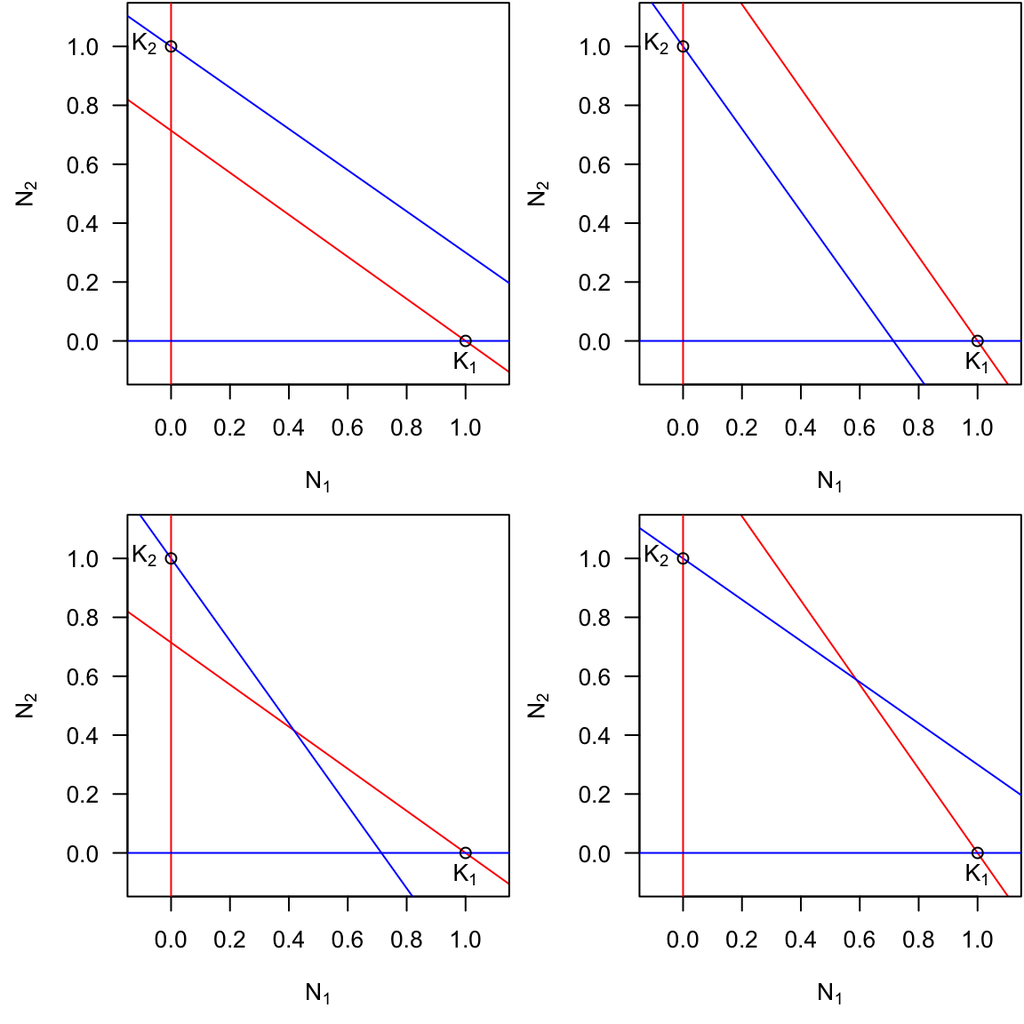

```r
N1_vec <- -1:2
K1 <- K2 <- 1

alpha12_weak <- alpha21_weak <- 0.7
alpha12_strong <- alpha21_strong <- 1.4

eq1_nc_A <- K1/alpha12_strong - (1/alpha12_strong)*N1_vec
eq2_nc_A <- K2 - alpha21_weak*N1_vec
eq1_nc_B <- K1/alpha12_weak - (1/alpha12_weak)*N1_vec
eq2_nc_B <- K2 - alpha21_strong*N1_vec
eq1_nc_C <- K1/alpha12_strong - (1/alpha12_strong)*N1_vec
eq2_nc_C <- K2 - alpha21_strong*N1_vec
eq1_nc_D <- K1/alpha12_weak - (1/alpha12_weak)*N1_vec
eq2_nc_D <- K2 - alpha21_weak*N1_vec

plot_empty <- function(x_vec, N1_nc, N2_nc) {
  plot(x = x_vec, y = N1_nc, xlab = bquote("N"[1]), ylab = bquote("N"[2]), xlim = c(-0.1, 1.1), ylim = c(-0.1, 1.1), las = 1, type = "l", col = "red")
  lines(x = x_vec, y = N2_nc, col = "blue")
  abline(v = 0, col = "red")
  abline(h = 0, col = "blue")
  points(x = 1, y = 0)
  text(x = 1, y = 0, labels = bquote("K"[1]), pos = 1)
  points(x = 0, y = 1)
  text(x = 0, y = 1, labels = bquote("K"[2]), pos = 2)
}

par(mfrow = c(2, 2), mar = c(4.5, 4.5, 0.1, 0.1))
plot_empty(x_vec = N1_vec, N1_nc = eq1_nc_A, N2_nc = eq2_nc_A)
plot_empty(x_vec = N1_vec, N1_nc = eq1_nc_B, N2_nc = eq2_nc_B)
plot_empty(x_vec = N1_vec, N1_nc = eq1_nc_C, N2_nc = eq2_nc_C)
plot_empty(x_vec = N1_vec, N1_nc = eq1_nc_D, N2_nc = eq2_nc_D)
```